# *Principal Component Analysis* (*PCA*)

Στην άσκηση αυτή θα μελετήσετε τον αλγόριθμο *ανάλυσης σε κύριες συνιστώσες* (*Principal Component Analysis*, *PCA*), υλοποιημένο σύμφωνα με τη *μέθοδο συνδιακύμανσης* (*covariance method*). Για να κατανοήσετε τη χρησιμότητα της μεθόδου θα εκπαιδεύσετε και θα αξιολογήσετε την ακρίβεια ενός μοντέλου *logistic regression* για ένα dataset πριν και μετά την εφαρμογή του αλγορίθμου *PCA*. Περισσότερες πληροφορίες για τη μέθοδο αυτή μπορείτε να αναζητήσετε [εδώ](https://ourarchive.otago.ac.nz/handle/10523/7534).

Η άσκηση περιλαμβάνει *δύο* προγράμματα *Python*: (a) το πρώτο δέχεται ένα dataset σε μορφή .*csv*, εφαρμόζει τον αλγόριθμο *PCA* και δημιουργεί το αρχείο *foo.csv* με το μετασχηματισμένο dataset, όπως προκύπτει από τις κύριες συνιστώσες που επέλεξε ο χρήστης να διατηρήσει, (b) το δεύτερο δέχεται ένα αρχείο σε μορφή .*csv*, διαχωρίζει το dataset σε *training* και *test set*, εκπαιδεύει ένα μοντέλο *logistic regression*, χρησιμοποιώντας το *training set* και υπολογίζει τον αριθμό των σφαλμάτων του μοντέλου πάνω στο *test set*.

Το dataset που θα χρησιμοποιήσετε παρέχεται σε δύο μορφές: (a) *demo3a.csv* και (b) *demo3b.csv*, το οποίο δεν περιλαμβάνει την πρώτη στήλη του *demo3a.csv*, δηλαδή τα *labels* που αντιστοιχούν σε κάθε είσοδο. Τα datasets αυτά αποτελούν απλοποιημένη μορφή του dataset που μπορεί να βρεθεί [εδώ](https://archive.ics.uci.edu/ml/datasets/wine).

### *Ανάλυση σε Κύριες Συνιστώσες*

Αρχικά, θα φορτώσετε τις βιβλιοθήκες που απαιτούνται για το πρόγραμμα που θα αναλύσει το dataset *demo3b.csv* στις κύριες συνιστώσες του.

```python
#https://machinelearningmastery.com/calculate-principal-component-analysis-scratch-python/
from numpy import genfromtxt
from numpy import mean
from numpy import cov
from numpy.linalg import eig
import numpy as np
import pandas as pd
import matplotlib.pyplot as plt
```

Στη συνέχεια, θα φορτώσετε το dataset

```python
data = genfromtxt('https://raw.githubusercontent.com/nkostopoulos/StochasticsLabPublic/master/lab2/demo3b.csv', delimiter=',')
```

```python
data.shape
```

```
(130, 13)
```

Έπειτα, θα υπολογίσετε το μέσο όρο κάθε στήλης (feature) του dataset και θα κανονικοποιήσετε κάθε feature με αυτόν

```python
M = mean(data.T, axis=1)
data_normal = data - M
```

Στη συνέχεια, θα υπολογίσετε το *πίνακα συνδιακύμανσης* (*covariance matrix*) για το dataset

```python
covariance = cov(data_normal.T)
print("The covariance matrix of the normalized data is the following: ")
print(covariance)
```

```
The covariance matrix of the normalized data is the following:
[[ 7.89911157e-01  1.64350328e-02  5.03965534e-02 -1.39557561e+00
   4.51870543e+00  2.35123047e-01  3.56524806e-01 -2.92133512e-02
   9.15320632e-02  1.07205560e+00  3.92238044e-03  1.22678110e-01
   2.36909466e+02]
 [ 1.64350328e-02  7.74344335e-01  3.18039952e-02  4.24165474e-01
  -2.21434109e-01  1.44160704e-02  3.75581395e-02  5.34385808e-03
   6.47891175e-02 -1.54797734e-01 -6.06599761e-02  6.96007454e-02
  -3.33629219e+01]
 [ 5.03965534e-02  3.18039952e-02  8.83052117e-02  3.73006798e-01
   1.40136434e+00  4.12452594e-02  8.26573643e-02  5.81539654e-03
   1.24709839e-02  1.22397007e-01  2.06346094e-03  3.02871079e-02
   3.18556160e+01]
 [-1.39557561e+00  4.24165474e-01  3.73006798e-01  1.15631181e+01
  -6.46193798e+00 -4.24464222e-01 -4.52046512e-01  1.24282469e-01
  -1.77910614e-01 -2.39565069e+00 -2.05387955e-02 -1.02069171e-03
  -5.11872284e+02]
 [ 4.51870543e+00 -2.21434109e-01  1.40136434e+00 -6.46193798e+00
   2.36586822e+02  2.55096899e+00  2.89720930e+00 -3.57263566e-01
   2.30737209e+00  8.63970543e+00  1.85996899e-01  9.56255814e-01
   2.31515659e+03]
 [ 2.35123047e-01  1.44160704e-02  4.12452594e-02 -4.24464222e-01
   2.55096899e+00  2.97453936e-01  3.40611628e-01 -2.64587657e-02
   1.30694305e-01  5.23527370e-01 -7.63816339e-04  1.28195856e-01
   9.73171139e+01]
 [ 3.56524806e-01  3.75581395e-02  8.26573643e-02 -4.52046512e-01
   2.89720930e+00  3.40611628e-01  5.44297674e-01 -2.88767442e-02
   2.16111628e-01  8.48084496e-01 -8.24186047e-04  1.88436434e-01
   1.41942171e+02]
 [-2.92133512e-02  5.34385808e-03  5.81539654e-03  1.24282469e-01
  -3.57263566e-01 -2.64587657e-02 -2.88767442e-02  1.18999463e-02
  -1.98501670e-02 -4.97212642e-02  9.44753727e-04 -2.42901670e-02
  -1.26918819e+01]
 [ 9.15320632e-02  6.47891175e-02  1.24709839e-02 -1.77910614e-01
   2.30737209e+00  1.30694305e-01  2.16111628e-01 -1.98501670e-02
   2.91137680e-01  2.39266834e-01 -9.77493143e-04  8.78196959e-02
   5.22928014e+01]
 [ 1.07205560e+00 -1.54797734e-01  1.22397007e-01 -2.39565069e+00
   8.63970543e+00  5.23527370e-01  8.48084496e-01 -4.97212642e-02
   2.39266834e-01  2.64316778e+00  2.68330829e-03  1.60809159e-01
   4.44340177e+02]
 [ 3.92238044e-03 -6.06599761e-02  2.06346094e-03 -2.05387955e-02
   1.85996899e-01 -7.63816339e-04 -8.24186047e-04  9.44753727e-04
  -9.77493143e-04  2.68330829e-03  2.84562519e-02 -8.13836136e-03
   6.93777746e+00]
 [ 1.22678110e-01  6.96007454e-02  3.02871079e-02 -1.02069171e-03
   9.56255814e-01  1.28195856e-01  1.88436434e-01 -2.42901670e-02
   8.78196959e-02  1.60809159e-01 -8.13836136e-03  2.25782952e-01
   3.83903673e+01]
 [ 2.36909466e+02 -3.33629219e+01  3.18556160e+01 -5.11872284e+02
   2.31515659e+03  9.73171139e+01  1.41942171e+02 -1.26918819e+01
   5.22928014e+01  4.44340177e+02  6.93777746e+00  3.83903673e+01
   1.24265433e+05]]
```

```python
covariance.shape
```

```
(13, 13)
```

Το επόμενο βήμα είναι να υπολογίσετε τις *ιδιοτιμές* (*eigenvalues*) και τα *ιδιοδιανύσματα* (*eigenvectors*) του dataset.

```python
values, vectors = eig(covariance)
print("The eigenvalues of the normalized data are the following: ")
print(values)
```

```
The eigenvalues of the normalized data are the following:
[1.24313073e+05 1.93456026e+02 9.50168321e+00 1.32500169e+00
 8.10595669e-01 4.51081713e-01 2.69157831e-01 1.60993380e-01
 1.11100343e-01 6.13399000e-03 2.19782528e-02 3.20312852e-02
 5.87421686e-02]
```

Στη συνέχεια, θα επιλέξετε τις πιο σημαντικές *ιδιοτιμές* και θα προσαρμόσετε αντίστοιχα τα *ιδιοδιανύσματα* του dataset.

```python
new_values = values[0:3]
print("The most important eigenvalues are the following: ")
print(new_values)
new_vectors = vectors[0:3]
print("The most important eigenvectors are the following: ")
print(new_vectors)
```

```
The most important eigenvalues are the following:
[1.24313073e+05 1.93456026e+02 9.50168321e+00]
The most important eigenvectors are the following:
[[-1.90615566e-03 -4.75319302e-04 -4.70065618e-02  2.25255930e-01
   9.82089183e-02 -2.20758056e-01 -8.52483156e-01 -3.65140031e-01
  -1.65925760e-01 -5.62139324e-03 -2.07811823e-02  2.48378617e-02
  -8.18675258e-04]
 [ 2.68379014e-04 -2.11118304e-03  3.21935310e-02  1.25115825e-01
   9.16405147e-01 -3.07909300e-01  1.86306127e-01  7.26209733e-02
  -1.81047372e-02 -1.16925805e-02  8.44468784e-02 -2.41209813e-02
   2.31770029e-02]
 [-2.56407459e-04 -4.21644285e-03  5.19948847e-02  4.67286333e-02
   2.01302236e-02 -3.45064791e-03 -1.57617050e-02  1.52544206e-01
  -7.18891029e-02 -1.38330530e-01 -6.68720003e-02  6.75337422e-01
  -6.97354965e-01]]
```

Τώρα, θα εφαρμόσετε τα νέα *ιδιοδιανύσματα* στο παλιό dataset για να πάρετε το νέο, μειωμένο σε μέγεθος dataset.

```python
new_data = new_vectors.dot(data_normal.T)
```

Να αποθηκεύσετε το νέο dataset σε ένα αρχείο *csv*.

```python
np.savetxt("foo.csv", new_data.T, delimiter=",")
```

#### *Ερωτήσεις*

- Να μελετήσετε το παραπάνω πρόγραμμα και να περιγράψετε, σύντομα, τα βήματα που ακολουθεί ο αλγόριθμος *PCA*, υλοποιημένος με τη μέθοδο *covariance*. Να συμπεριλάβετε και τις μαθηματικές πράξεις.
- Να εφαρμόσετε τον αλγόριθμο *PCA* πάνω στα δεδομένα του αρχείου *demo3b.csv*. Στη συνέχεια, να καταγράψετε τον *πίνακα συνδιακύμανσης* του dataset και τις ιδιοτιμές του πίνακα αυτού. Τι υποδηλώνουν οι θετικές και τι οι αρνητικές τιμές του *πίνακα συνδιακύμανσης*; Να διατάξετε τις *ιδιοτιμές* σε φθίνουσα σειρά. Τι παρατηρείτε για τις τρεις πρώτες σε σχέση με τις υπόλοιπες; Πόσες *κύριες συνιστώσες* επιλέγει να διατηρήσει ο αλγόριθμος;

## Ερώτηση 1η: Βήματα PCA:

Έστω ένας πίνακας $X$ με τα features που μας ενδιαφέρουμε να μετασχηματίσουμε βάσει της PCA. Γενικότερα, ένας τέτοιος πίνακας μπορεί να έχει διαστάσεις $n\times m$, στην περίπτωσή μας ο πίνακας των δεδομένων έχει διάσταση $130\times13$ δηλαδή 130 γραμμές και 13 στήλες.

#### Βήμα 2: Υπολογισμός Covariance Matrix.

Το Covariance (ή συνδιασπορά) μας δίνει την μεταβλητότητα ανάμεσα σε δύο μεταβλητές (εδώ οι στήλες του πίνακα X). Αν ο πίνακας έχει m στήλες τότε ο Covariance Matrix είναι διάστασης $m\times m$, στην περίπτωσή μας είναι διάστασης $13\times 13$. Το Covariance για δύο μεταβλητές $x,y$ δίνεται από τη σχέση: $$\operatorname{cov}(X, Y)=\frac{\sum_{i=1}^{n}\left(X_{i}-\bar{X}\right)\left(Y_{i}-\bar{Y}\right)}{(n-1)}$$ Παρατηρούμε ότι αν $x=y$ τότε αυτό μας δίνει την σχέση για το variance, επομένως τα διαγώνια στοιχεία του covariance εκφράζουν τη διασπορά. Για παράδειγμα, ο Covariance Matrix για έναν πίνακα $n\times 3$ θα ήταν ο: $$C=\left(\begin{array}{ccc} \operatorname{cov}(x, x) & \operatorname{cov}(x, y) & \operatorname{cov}(x, z) \\ \operatorname{cov}(y, x) & \operatorname{cov}(y, y) & \operatorname{cov}(y, z) \\ \operatorname{cov}(z, x) & \operatorname{cov}(z, y) & \operatorname{cov}(z, z) \end{array}\right)$$ επομένως έτσι καταλαβαίνουμε τι μορφή θα έχει ο covariance matrix για τα δικά μας δεδομένα, τον πίνακα $X_{scaled}$,
για τη συνέχεια έχουμε ότι: $$ C = cov(X_{scaled})$$

#### Βήμα 3: Υπολογισμός ιδιοτιμών και ιδιοδιανυσμάτων του Covariance Matrix

Ένα ιδιοδιάνυσμα ενός γραμμικού μετασχηματισμού, είναι το (μη-μηδενικό) διάνυσμα αυτό που αλλάζει το πολύ κατά μια βαθμωτή ποσότητα όταν εφαρμόζεται σε αυτό ο ίδιος γραμμικός μετασχηματισμός. Η ιδιοτιμή (συνήθως συμβολίζεται με $\lambda$) εκφράζει τον παράγοντα κατά τον οποίο αλλάζει το διάνυσμα. Εμείς όμως καθώς ασχολούμαστε με πίνακες είναι σκόπιμο να αναρωτηθούμε με τι σχετίζονται οι ιδιοτιμές και τα ιδιοδιανύσματα. Ουσιαστικά κάθε πίνακας εκφράζει κάποιον μετασχηματισμό όταν εφαρμοστεί πάνω σε ένα διάνυσμα. Για παράδειγμα ο μοναδιαίος πίνακας $\mathbb{I}= \begin{bmatrix} 1 & 0 \\ 0 & 1 \end{bmatrix}$ είναι ο τετριμμένος μετασχηματισμός δηλαδή αφήνει το διάνυσμα αναλλοίωτο, ο πίνακας $k\cdot\mathbb{I} = \begin{bmatrix} k & 0 \\ 0 & k \end{bmatrix}$ αν εφαρμοστεί σε ένα 2-διάστατο διάνυσμα προκαλεί stretch κατά $k$, ο πίνακας $\begin{bmatrix} \cos \theta & \sin\theta \\ -\sin \theta & \cos \theta \end{bmatrix}$ αποτελεί clockwise στροφή κατά $\theta$ κι ούτω καθεξής.  
Οι ιδιοτιμές βρίσκονται μόνο για τετραγωνικούς πίνακες, όμως ευτυχώς όπως είδαμε ο covariance matrix είναι τετραγωνικός εκ κατασκευής.  
Αν $\mathbb{A}$ ένας γραμμικός μετασχηματισμός (ή πίνακας) και υπάρχουν $X\in \mathbb{R}^n \neq 0$ και $\lambda \in \mathbb{R}$, ώστε: $\mathbb{AX}=\lambda\mathbb{X}$, τότε το $\mathbb{X}$ είναι ιδιοδιάνυσμα του πίνακα $\mathbb{A}$ και το $\lambda$ ιδιοτιμή.  
*Επομένως, στο βήμα αυτό υπολογίζουμε τις ιδιοτιμές και τα ιδιοανύσματα του C.* Στη συνέχεια, όπως παρατηρούμε και παρακάτω, βλέπουμε ότι οι ιδιοτιμές διαφέρουν στο μέγεθος, επομένως εδώ γίνεται η επιλογή των κυρίων συνιστωσών (principal componets), δηλαδή διαλέγουμε όσες συνιστώσες θέλουμε, ξεκινώντας από τη μεγαλύτερη. Έπειτα κατασκευάζουμε έναν πίνακα ο οποίος λέγεται feature vector ο οποίος αποτελείται από τα ιδιοδιανύσματα που αντιστοιχούν στις ιδιοτιμές που επιλέξαμε. Αν για παράδειγμα θέλουμε να έχουμε 2 κύριες συνιστώσες, τότε διαλέγουμε τις δύο μεγαλύτερες ιδιοτιμές και τα δύο ιδιοδιανύσματα που τους αντιστοιχούν και κατασκευάζουμε τον πίνακα: $FV = (eig_1, eig_2)$.

```python
values, vectors = eig(covariance)
print("The eigenvalues of the normalized data are the following: ")
print(sorted(values,reverse=True))
```

```
The eigenvalues of the normalized data are the following:
[124313.07344459962, 193.45602626538684, 9.501683210059726, 1.3250016880448785, 0.810595668646941, 0.45108171265226005, 0.2691578314854767, 0.16099338038871613, 0.11110034340026105, 0.0587421685522019, 0.03203128519817312, 0.021978252812754513, 0.0061339899981011975]
```

#### Βήμα 4: Μετασχηματισμός των Δεδομένων.

Αφού έχουμε αποφασίσει πόσες συνιστώσες θα κρατήσουμε και έχουμε σχηματίσει το feature vector, τότε παίρνουμε τον ανάστροφό του, ώστε τα ιδιοδιανύσματα να βρίσκονται στις γραμμές, και τον πολλαπλασιάζουμε με τον ανάστροφο μετασχηματισμένο πίνακα των δεδομένων μας, δηλαδή:
$$X' = FV^T\times X_{scaled}^T$$ Προκειμένου να βγάλει διαστατικά νόημα αυτό, το κάθε eigenvector είναι διάστασης $13\times 1$ αφού υπολογίζεται από τον covariance matrix ο οποίος είναι $13\times 13$, και αν διαλέξουμε $p$ κύριες συνιστώσες τότε ο $FV$ είναι διάστασης $p\times 13$. Τα μετασχηματισμένα μας δεδομένα είναι διάστασης $13\times 130$ (εφόσον πήραμε τον ανάστροφο) άρα τα μετασχηματισμένα μας δεδομένα είναι διάστασης $p\times 130$, όπως φαίνεται και παρακάτω, όπου διαλέξαμε 3 κύριες συνιστώσες ($p=3$).

```python
new_data.shape
```

```
(3, 130)
```

#### Βήμα 5 : Explained Variance (προαιρετικό)

Έχω δει ότι σε πολλές χρήσεις της PCA αναφέρεται ο όρος Explained Variance οπότε αποφάσισα να αναλύσω και αυτή την έννοια για καλύτερη κατανόηση. Όπως είδαμε στο βήμα 2, τα διαγώνια στοιχεία του Covariance matrix αποτελούν την διασπορά της κάθε μεταβλητής, ας υπολογίσουμε το άθροισμά τους, δηλαδή το ίχνος του covariance matrix:

```python
np.trace(covariance)
```

```
124519.27797039617
```

Ας υποθέσουμε τώρα, ότι εφαρμόζουμε PCA για όλες τις κύριες συνιστώσες, τα νέα μας δεδομένα θα πολλαπλασιαστούν με τον $FV$ που θα έχει και τις 13 κύριες συνιστώσες.  
Το ίχνος του Covariance Matrix για αυτά τα νέα δεδομένα θα είναι:

```python
np.trace(cov(vectors.dot(data_normal.T)))
```

```
124519.27797039614
```

Παρατηρούμε ότι το ίχνος παραμένει ίδιο, δηλαδή το ολικό variance διατηρείται κάτω από τον μετασχηματισμό PCA.  
Επίσης, αν πάρουμε το άθροισμα όλων των ιδιοτιμών που υπολογίσαμε:

```python
sum(values)
```

```
124519.27797039626
```

Παρατηρούμε δηλαδή ότι το άθροισμα όλων των ιδιοτιμών ισούται με το ολικό variance. Γι'αυτό συνηθίζεται να υπολογίζεται το Explained Variance όπου ορίζεται ως τον λόγο του αθροίσματος των ιδιοτιμών που διαλέξαμε ως κύριες συνιστώσες προς το άθροισμα όλων των ιδιοτιμών. Για παράδειγμα, το explained variance της PCA που εφαρμόσαμε όπου διαλέξαμε τις 3 κύριες συνιστώσες, είναι:

```python
sum(new_values)/sum(values)
```

```
0.9999739251915518
```

Αυτό κατά κάποιο τρόπο σημαίνει ότι με τις 3 κύριες συνιστώσες, μπορούμε να εκφράζουμε το 99.9\% του explained variance του συνόλου των δεδομένων. Βοηθάει ένα διάγραμμα που να φαίνεται το explained variance ως συνάρτηση του αριθμού κυρίων συνιστωσών που επιλέγουμε, γι'αυτό κι έχει και νόημα ο υπολογισμός του cumulative sum των ιδιοτιμών.

```python
plt.plot([i for i in range(0,len(values))],100*np.cumsum(values)/sum(values))
plt.xticks(range(0,14));
plt.xlabel('Number of Principal Components')
plt.ylabel('Explained Variance(%)')
plt.grid()
```

[figure not shown]

*Principal Component Analysis* (*PCA*)

Στην άσκηση αυτή θα μελετήσετε τον αλγόριθμο *ανάλυσης σε κύριες συνιστώσες* (*Principal Component Analysis*, *PCA*), υλοποιημένο σύμφωνα με τη *μέθοδο συνδιακύμανσης* (*covariance method*). Για να κατανοήσετε τη χρησιμότητα της μεθόδου θα εκπαιδεύσετε και θα αξιολογήσετε την ακρίβεια ενός μοντέλου *logistic regression* για ένα dataset πριν και μετά την εφαρμογή του αλγορίθμου *PCA*. Περισσότερες πληροφορίες για τη μέθοδο αυτή μπορείτε να αναζητήσετε [εδώ](https://ourarchive.otago.ac.nz/handle/10523/7534).

Η άσκηση περιλαμβάνει *δύο* προγράμματα *Python*: (a) το πρώτο δέχεται ένα dataset σε μορφή .*csv*, εφαρμόζει τον αλγόριθμο *PCA* και δημιουργεί το αρχείο *foo.csv* με το μετασχηματισμένο dataset, όπως προκύπτει από τις κύριες συνιστώσες που επέλεξε ο χρήστης να διατηρήσει, (b) το δεύτερο δέχεται ένα αρχείο σε μορφή .*csv*, διαχωρίζει το dataset σε *training* και *test set*, εκπαιδεύει ένα μοντέλο *logistic regression*, χρησιμοποιώντας το *training set* και υπολογίζει τον αριθμό των σφαλμάτων του μοντέλου πάνω στο *test set*.

Το dataset που θα χρησιμοποιήσετε παρέχεται σε δύο μορφές: (a) *demo3a.csv* και (b) *demo3b.csv*, το οποίο δεν περιλαμβάνει την πρώτη στήλη του *demo3a.csv*, δηλαδή τα *labels* που αντιστοιχούν σε κάθε είσοδο. Τα datasets αυτά αποτελούν απλοποιημένη μορφή του dataset που μπορεί να βρεθεί [εδώ](https://archive.ics.uci.edu/ml/datasets/wine).

*Ανάλυση σε Κύριες Συνιστώσες*

Αρχικά, θα φορτώσετε τις βιβλιοθήκες που απαιτούνται για το πρόγραμμα που θα αναλύσει το dataset *demo3b.csv* στις κύριες συνιστώσες του.

```
#https://machinelearningmastery.com/calculate-principal-component-analysis-scratch-python/
from numpy import genfromtxt
from numpy import mean
from numpy import cov
from numpy.linalg import eig
import numpy as np
import pandas as pd
import matplotlib.pyplot as plt
```

Στη συνέχεια, θα φορτώσετε το dataset

```
data = genfromtxt('https://raw.githubusercontent.com/nkostopoulos/StochasticsLabPublic/master/lab2/demo3b.csv', delimiter=',')
```

```
data.shape
```

```
(130, 13)
```

Έπειτα, θα υπολογίσετε το μέσο όρο κάθε στήλης (feature) του dataset και θα κανονικοποιήσετε κάθε feature με αυτόν

```
M = mean(data.T, axis=1)
data_normal = data - M
```

Στη συνέχεια, θα υπολογίσετε το *πίνακα συνδιακύμανσης* (*covariance matrix*) για το dataset

```
covariance = cov(data_normal.T)
print("The covariance matrix of the normalized data is the following: ")
print(covariance)
```

```
The covariance matrix of the normalized data is the following:
[[ 7.89911157e-01  1.64350328e-02  5.03965534e-02 -1.39557561e+00
   4.51870543e+00  2.35123047e-01  3.56524806e-01 -2.92133512e-02
   9.15320632e-02  1.07205560e+00  3.92238044e-03  1.22678110e-01
   2.36909466e+02]
 [ 1.64350328e-02  7.74344335e-01  3.18039952e-02  4.24165474e-01
  -2.21434109e-01  1.44160704e-02  3.75581395e-02  5.34385808e-03
   6.47891175e-02 -1.54797734e-01 -6.06599761e-02  6.96007454e-02
  -3.33629219e+01]
 [ 5.03965534e-02  3.18039952e-02  8.83052117e-02  3.73006798e-01
   1.40136434e+00  4.12452594e-02  8.26573643e-02  5.81539654e-03
   1.24709839e-02  1.22397007e-01  2.06346094e-03  3.02871079e-02
   3.18556160e+01]
 [-1.39557561e+00  4.24165474e-01  3.73006798e-01  1.15631181e+01
  -6.46193798e+00 -4.24464222e-01 -4.52046512e-01  1.24282469e-01
  -1.77910614e-01 -2.39565069e+00 -2.05387955e-02 -1.02069171e-03
  -5.11872284e+02]
 [ 4.51870543e+00 -2.21434109e-01  1.40136434e+00 -6.46193798e+00
   2.36586822e+02  2.55096899e+00  2.89720930e+00 -3.57263566e-01
   2.30737209e+00  8.63970543e+00  1.85996899e-01  9.56255814e-01
   2.31515659e+03]
 [ 2.35123047e-01  1.44160704e-02  4.12452594e-02 -4.24464222e-01
   2.55096899e+00  2.97453936e-01  3.40611628e-01 -2.64587657e-02
   1.30694305e-01  5.23527370e-01 -7.63816339e-04  1.28195856e-01
   9.73171139e+01]
 [ 3.56524806e-01  3.75581395e-02  8.26573643e-02 -4.52046512e-01
   2.89720930e+00  3.40611628e-01  5.44297674e-01 -2.88767442e-02
   2.16111628e-01  8.48084496e-01 -8.24186047e-04  1.88436434e-01
   1.41942171e+02]
 [-2.92133512e-02  5.34385808e-03  5.81539654e-03  1.24282469e-01
  -3.57263566e-01 -2.64587657e-02 -2.88767442e-02  1.18999463e-02
  -1.98501670e-02 -4.97212642e-02  9.44753727e-04 -2.42901670e-02
  -1.26918819e+01]
 [ 9.15320632e-02  6.47891175e-02  1.24709839e-02 -1.77910614e-01
   2.30737209e+00  1.30694305e-01  2.16111628e-01 -1.98501670e-02
   2.91137680e-01  2.39266834e-01 -9.77493143e-04  8.78196959e-02
   5.22928014e+01]
 [ 1.07205560e+00 -1.54797734e-01  1.22397007e-01 -2.39565069e+00
   8.63970543e+00  5.23527370e-01  8.48084496e-01 -4.97212642e-02
   2.39266834e-01  2.64316778e+00  2.68330829e-03  1.60809159e-01
   4.44340177e+02]
 [ 3.92238044e-03 -6.06599761e-02  2.06346094e-03 -2.05387955e-02
   1.85996899e-01 -7.63816339e-04 -8.24186047e-04  9.44753727e-04
  -9.77493143e-04  2.68330829e-03  2.84562519e-02 -8.13836136e-03
   6.93777746e+00]
 [ 1.22678110e-01  6.96007454e-02  3.02871079e-02 -1.02069171e-03
   9.56255814e-01  1.28195856e-01  1.88436434e-01 -2.42901670e-02
   8.78196959e-02  1.60809159e-01 -8.13836136e-03  2.25782952e-01
   3.83903673e+01]
 [ 2.36909466e+02 -3.33629219e+01  3.18556160e+01 -5.11872284e+02
   2.31515659e+03  9.73171139e+01  1.41942171e+02 -1.26918819e+01
   5.22928014e+01  4.44340177e+02  6.93777746e+00  3.83903673e+01
   1.24265433e+05]]
```

```
covariance.shape
```

```
(13, 13)
```

Το επόμενο βήμα είναι να υπολογίσετε τις *ιδιοτιμές* (*eigenvalues*) και τα *ιδιοδιανύσματα* (*eigenvectors*) του dataset.

```
values, vectors = eig(covariance)
print("The eigenvalues of the normalized data are the following: ")
print(values)
```

```
The eigenvalues of the normalized data are the following:
[1.24313073e+05 1.93456026e+02 9.50168321e+00 1.32500169e+00
 8.10595669e-01 4.51081713e-01 2.69157831e-01 1.60993380e-01
 1.11100343e-01 6.13399000e-03 2.19782528e-02 3.20312852e-02
 5.87421686e-02]
```

Στη συνέχεια, θα επιλέξετε τις πιο σημαντικές *ιδιοτιμές* και θα προσαρμόσετε αντίστοιχα τα *ιδιοδιανύσματα* του dataset.

```
new_values = values[0:3]
print("The most important eigenvalues are the following: ")
print(new_values)
new_vectors = vectors[0:3]
print("The most important eigenvectors are the following: ")
print(new_vectors)
```

```
The most important eigenvalues are the following:
[1.24313073e+05 1.93456026e+02 9.50168321e+00]
The most important eigenvectors are the following:
[[-1.90615566e-03 -4.75319302e-04 -4.70065618e-02  2.25255930e-01
   9.82089183e-02 -2.20758056e-01 -8.52483156e-01 -3.65140031e-01
  -1.65925760e-01 -5.62139324e-03 -2.07811823e-02  2.48378617e-02
  -8.18675258e-04]
 [ 2.68379014e-04 -2.11118304e-03  3.21935310e-02  1.25115825e-01
   9.16405147e-01 -3.07909300e-01  1.86306127e-01  7.26209733e-02
  -1.81047372e-02 -1.16925805e-02  8.44468784e-02 -2.41209813e-02
   2.31770029e-02]
 [-2.56407459e-04 -4.21644285e-03  5.19948847e-02  4.67286333e-02
   2.01302236e-02 -3.45064791e-03 -1.57617050e-02  1.52544206e-01
  -7.18891029e-02 -1.38330530e-01 -6.68720003e-02  6.75337422e-01
  -6.97354965e-01]]
```

Τώρα, θα εφαρμόσετε τα νέα *ιδιοδιανύσματα* στο παλιό dataset για να πάρετε το νέο, μειωμένο σε μέγεθος dataset.

```
new_data = new_vectors.dot(data_normal.T)
```

Να αποθηκεύσετε το νέο dataset σε ένα αρχείο *csv*.

```
np.savetxt("foo.csv", new_data.T, delimiter=",")
```

*Ερωτήσεις*

- Να μελετήσετε το παραπάνω πρόγραμμα και να περιγράψετε, σύντομα, τα βήματα που ακολουθεί ο αλγόριθμος *PCA*, υλοποιημένος με τη μέθοδο *covariance*. Να συμπεριλάβετε και τις μαθηματικές πράξεις.

- Να εφαρμόσετε τον αλγόριθμο *PCA* πάνω στα δεδομένα του αρχείου *demo3b.csv*. Στη συνέχεια, να καταγράψετε τον *πίνακα συνδιακύμανσης* του dataset και τις ιδιοτιμές του πίνακα αυτού. Τι υποδηλώνουν οι θετικές και τι οι αρνητικές τιμές του *πίνακα συνδιακύμανσης*; Να διατάξετε τις *ιδιοτιμές* σε φθίνουσα σειρά. Τι παρατηρείτε για τις τρεις πρώτες σε σχέση με τις υπόλοιπες; Πόσες *κύριες συνιστώσες* επιλέγει να διατηρήσει ο αλγόριθμος;

Ερώτηση 1η: Βήματα PCA:

Έστω ένας πίνακας $X$ με τα features που μας ενδιαφέρουμε να μετασχηματίσουμε βάσει της PCA. Γενικότερα, ένας τέτοιος πίνακας μπορεί να έχει διαστάσεις $n\times m$, στην περίπτωσή μας ο πίνακας των δεδομένων έχει διάσταση $130\times13$ δηλαδή 130 γραμμές και 13 στήλες.

Βήμα 1: Αφαίρεση Μέσης Τιμής

Βήμα 2: Υπολογισμός Covariance Matrix.

Το Covariance (ή συνδιασπορά) μας δίνει την μεταβλητότητα ανάμεσα σε δύο μεταβλητές (εδώ οι στήλες του πίνακα X). Αν ο πίνακας έχει m στήλες τότε ο Covariance Matrix είναι διάστασης $m\times m$, στην περίπτωσή μας είναι διάστασης $13\times 13$. Το Covariance για δύο μεταβλητές $x,y$ δίνεται από τη σχέση: $$\operatorname{cov}(X, Y)=\frac{\sum_{i=1}^{n}\left(X_{i}-\bar{X}\right)\left(Y_{i}-\bar{Y}\right)}{(n-1)}$$ Παρατηρούμε ότι αν $x=y$ τότε αυτό μας δίνει την σχέση για το variance, επομένως τα διαγώνια στοιχεία του covariance εκφράζουν τη διασπορά. Για παράδειγμα, ο Covariance Matrix για έναν πίνακα $n\times 3$ θα ήταν ο: $$C=\left(\begin{array}{ccc} \operatorname{cov}(x, x) & \operatorname{cov}(x, y) & \operatorname{cov}(x, z) \\ \operatorname{cov}(y, x) & \operatorname{cov}(y, y) & \operatorname{cov}(y, z) \\ \operatorname{cov}(z, x) & \operatorname{cov}(z, y) & \operatorname{cov}(z, z) \end{array}\right)$$ επομένως έτσι καταλαβαίνουμε τι μορφή θα έχει ο covariance matrix για τα δικά μας δεδομένα, τον πίνακα $X_{scaled}$,
για τη συνέχεια έχουμε ότι: $$ C = cov(X_{scaled})$$

Βήμα 3: Υπολογισμός ιδιοτιμών και ιδιοδιανυσμάτων του Covariance Matrix

Ένα ιδιοδιάνυσμα ενός γραμμικού μετασχηματισμού, είναι το (μη-μηδενικό) διάνυσμα αυτό που αλλάζει το πολύ κατά μια βαθμωτή ποσότητα όταν εφαρμόζεται σε αυτό ο ίδιος γραμμικός μετασχηματισμός. Η ιδιοτιμή (συνήθως συμβολίζεται με $\lambda$) εκφράζει τον παράγοντα κατά τον οποίο αλλάζει το διάνυσμα. Εμείς όμως καθώς ασχολούμαστε με πίνακες είναι σκόπιμο να αναρωτηθούμε με τι σχετίζονται οι ιδιοτιμές και τα ιδιοδιανύσματα. Ουσιαστικά κάθε πίνακας εκφράζει κάποιον μετασχηματισμό όταν εφαρμοστεί πάνω σε ένα διάνυσμα. Για παράδειγμα ο μοναδιαίος πίνακας $\mathbb{I}= \begin{bmatrix} 1 & 0 \\ 0 & 1 \end{bmatrix}$ είναι ο τετριμμένος μετασχηματισμός δηλαδή αφήνει το διάνυσμα αναλλοίωτο, ο πίνακας $k\cdot\mathbb{I} = \begin{bmatrix} k & 0 \\ 0 & k \end{bmatrix}$ αν εφαρμοστεί σε ένα 2-διάστατο διάνυσμα προκαλεί stretch κατά $k$, ο πίνακας $\begin{bmatrix} \cos \theta & \sin\theta \\ -\sin \theta & \cos \theta \end{bmatrix}$ αποτελεί clockwise στροφή κατά $\theta$ κι ούτω καθεξής.  
Οι ιδιοτιμές βρίσκονται μόνο για τετραγωνικούς πίνακες, όμως ευτυχώς όπως είδαμε ο covariance matrix είναι τετραγωνικός εκ κατασκευής.  
Αν $\mathbb{A}$ ένας γραμμικός μετασχηματισμός (ή πίνακας) και υπάρχουν $X\in \mathbb{R}^n \neq 0$ και $\lambda \in \mathbb{R}$, ώστε: $\mathbb{AX}=\lambda\mathbb{X}$, τότε το $\mathbb{X}$ είναι ιδιοδιάνυσμα του πίνακα $\mathbb{A}$ και το $\lambda$ ιδιοτιμή.  
*Επομένως, στο βήμα αυτό υπολογίζουμε τις ιδιοτιμές και τα ιδιοανύσματα του C.* Στη συνέχεια, όπως παρατηρούμε και παρακάτω, βλέπουμε ότι οι ιδιοτιμές διαφέρουν στο μέγεθος, επομένως εδώ γίνεται η επιλογή των κυρίων συνιστωσών (principal componets), δηλαδή διαλέγουμε όσες συνιστώσες θέλουμε, ξεκινώντας από τη μεγαλύτερη. Έπειτα κατασκευάζουμε έναν πίνακα ο οποίος λέγεται feature vector ο οποίος αποτελείται από τα ιδιοδιανύσματα που αντιστοιχούν στις ιδιοτιμές που επιλέξαμε. Αν για παράδειγμα θέλουμε να έχουμε 2 κύριες συνιστώσες, τότε διαλέγουμε τις δύο μεγαλύτερες ιδιοτιμές και τα δύο ιδιοδιανύσματα που τους αντιστοιχούν και κατασκευάζουμε τον πίνακα: $FV = (eig_1, eig_2)$.

```
values, vectors = eig(covariance)
print("The eigenvalues of the normalized data are the following: ")
print(sorted(values,reverse=True))
```

```
The eigenvalues of the normalized data are the following:
[124313.07344459962, 193.45602626538684, 9.501683210059726, 1.3250016880448785, 0.810595668646941, 0.45108171265226005, 0.2691578314854767, 0.16099338038871613, 0.11110034340026105, 0.0587421685522019, 0.03203128519817312, 0.021978252812754513, 0.0061339899981011975]
```

Βήμα 4: Μετασχηματισμός των Δεδομένων.

Αφού έχουμε αποφασίσει πόσες συνιστώσες θα κρατήσουμε και έχουμε σχηματίσει το feature vector, τότε παίρνουμε τον ανάστροφό του, ώστε τα ιδιοδιανύσματα να βρίσκονται στις γραμμές, και τον πολλαπλασιάζουμε με τον ανάστροφο μετασχηματισμένο πίνακα των δεδομένων μας, δηλαδή:
$$X' = FV^T\times X_{scaled}^T$$ Προκειμένου να βγάλει διαστατικά νόημα αυτό, το κάθε eigenvector είναι διάστασης $13\times 1$ αφού υπολογίζεται από τον covariance matrix ο οποίος είναι $13\times 13$, και αν διαλέξουμε $p$ κύριες συνιστώσες τότε ο $FV$ είναι διάστασης $p\times 13$. Τα μετασχηματισμένα μας δεδομένα είναι διάστασης $13\times 130$ (εφόσον πήραμε τον ανάστροφο) άρα τα μετασχηματισμένα μας δεδομένα είναι διάστασης $p\times 130$, όπως φαίνεται και παρακάτω, όπου διαλέξαμε 3 κύριες συνιστώσες ($p=3$).

```
new_data.shape
```

```
(3, 130)
```

Βήμα 5 : Explained Variance (προαιρετικό)

Έχω δει ότι σε πολλές χρήσεις της PCA αναφέρεται ο όρος Explained Variance οπότε αποφάσισα να αναλύσω και αυτή την έννοια για καλύτερη κατανόηση. Όπως είδαμε στο βήμα 2, τα διαγώνια στοιχεία του Covariance matrix αποτελούν την διασπορά της κάθε μεταβλητής, ας υπολογίσουμε το άθροισμά τους, δηλαδή το ίχνος του covariance matrix:

```
np.trace(covariance)
```

```
124519.27797039617
```

Ας υποθέσουμε τώρα, ότι εφαρμόζουμε PCA για όλες τις κύριες συνιστώσες, τα νέα μας δεδομένα θα πολλαπλασιαστούν με τον $FV$ που θα έχει και τις 13 κύριες συνιστώσες.  
Το ίχνος του Covariance Matrix για αυτά τα νέα δεδομένα θα είναι:

```
np.trace(cov(vectors.dot(data_normal.T)))
```

```
124519.27797039614
```

Παρατηρούμε ότι το ίχνος παραμένει ίδιο, δηλαδή το ολικό variance διατηρείται κάτω από τον μετασχηματισμό PCA.  
Επίσης, αν πάρουμε το άθροισμα όλων των ιδιοτιμών που υπολογίσαμε:

```
sum(values)
```

```
124519.27797039626
```

Παρατηρούμε δηλαδή ότι το άθροισμα όλων των ιδιοτιμών ισούται με το ολικό variance. Γι'αυτό συνηθίζεται να υπολογίζεται το Explained Variance όπου ορίζεται ως τον λόγο του αθροίσματος των ιδιοτιμών που διαλέξαμε ως κύριες συνιστώσες προς το άθροισμα όλων των ιδιοτιμών. Για παράδειγμα, το explained variance της PCA που εφαρμόσαμε όπου διαλέξαμε τις 3 κύριες συνιστώσες, είναι:

```
sum(new_values)/sum(values)
```

```
0.9999739251915518
```

Αυτό κατά κάποιο τρόπο σημαίνει ότι με τις 3 κύριες συνιστώσες, μπορούμε να εκφράζουμε το 99.9\% του explained variance του συνόλου των δεδομένων. Βοηθάει ένα διάγραμμα που να φαίνεται το explained variance ως συνάρτηση του αριθμού κυρίων συνιστωσών που επιλέγουμε, γι'αυτό κι έχει και νόημα ο υπολογισμός του cumulative sum των ιδιοτιμών.

```
plt.plot([i for i in range(0,len(values))],100*np.cumsum(values)/sum(values))
plt.xticks(range(0,14));
plt.xlabel('Number of Principal Components')
plt.ylabel('Explained Variance(%)')
plt.grid()
```

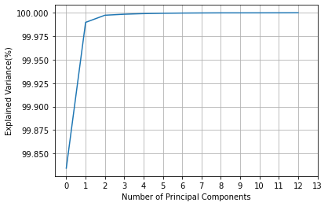

Ουσιαστικά η PCA εντοπίζει την διεύθυνση προς την οποία μεγιστοποιείται η διασπορά, και στη συνέχεια την επόμενη κατεύθυνση οπού μεγιστοποιείται η διασπορά κ.ο.κ.

Ερώτηση 2η:

*Να εφαρμόσετε τον αλγόριθμο PCA πάνω στα δεδομένα του αρχείου demo3b.csv. Στη συνέχεια, να καταγράψετε τον πίνακα συνδιακύμανσης του dataset και τις ιδιοτιμές του πίνακα αυτού. Τι υποδηλώνουν οι θετικές και τι οι αρνητικές τιμές του πίνακα συνδιακύμανσης; Να διατάξετε τις ιδιοτιμές σε φθίνουσα σειρά. Τι παρατηρείτε για τις τρεις πρώτες σε σχέση με τις υπόλοιπες; Πόσες κύριες συνιστώσες επιλέγει να διατηρήσει ο αλγόριθμος;*

- Οι θετικές τιμές του πίνακα συνδιακύμανσης δείχνουν ότι δύο μεταβλητές τείνουν να μεταβάλλονται με τον ίδιο τρόπο, οι αρνητικές δείχνουν ότι τείνουν να μεταβάλλονται αντίστροφα (όσο αυξάνει η μία η άλλη μειώνεται). Σαφώς αν η διακύμανση είναι μηδενική αυτό σημαίνει ότι οι δύο μεταβλητές είναι ασυσχέτιστες.

- Οι ιδιοτιμές του Covariance Matrix σε φθίνουσα σειρά:

```
sorted(values,reverse=True)
```

```
[124313.07344459962,
 193.45602626538684,
 9.501683210059726,
 1.3250016880448785,
 0.810595668646941,
 0.45108171265226005,
 0.2691578314854767,
 0.16099338038871613,
 0.11110034340026105,
 0.0587421685522019,
 0.03203128519817312,
 0.021978252812754513,
 0.0061339899981011975]
```

Logistic Regression

*Ερώτηση*

Να εκτελέσετε παραπάνω τμήματα κώδικα με είσοδο τα αρχεία (a) *demo3a.csv* και (b) *foo.csv*. Τι παρατηρείτε για την ακρίβεια του μοντέλου στις δύο περιπτώσεις; Δοκιμάστε και για την περίπτωση που κρατάμε (α) 1 και (β) 2 *κύριες συνιστώσες*. Τι παρατηρείτε;

Αρχικά, θα φορτώσετε τις απαραίτητες βιβλιοθήκες.

```
import numpy as np
import matplotlib.pyplot as plt
from sklearn.model_selection import train_test_split
from sklearn.decomposition import PCA
from sklearn.preprocessing import StandardScaler
from sklearn.linear_model import LogisticRegression
```

Στη συνέχεια, θα φορτώσετε τα datasets που θα χρησιμοποιηθούν για την εκπαίδευση του μοντέλου *logistic regression*. Στην πρώτη περίπτωση, θα εκπαιδεύσετε το μοντέλο, χρησιμοποιώντας το αρχείο *demo3a.csv*. Στη δεύτερη περίπτωση, θα φορτώσετε το αρχείο *foo.csv* που πήρατε ως έξοδο από το προηγούμενο τμήμα κώδικα της άσκησης (*Ανάλυση σε Κύριες Συνιστώσες*), προσθέτοντας στην πρώτη στήλη του αρχείου τα labels που υπάρχουν στην πρώτη στήλη του αρχείου [*demo3a.csv*](https://raw.githubusercontent.com/nkostopoulos/StochasticsLabPublic/master/lab2/demo3a.csv).

(a) Dataset demo3a.csv

```
dfa = pd.read_csv("https://raw.githubusercontent.com/nkostopoulos/StochasticsLabPublic/master/lab2/demo3a.csv")
```

Έπειτα, θα χωρίσετε το dataset σε *training* και *test set*.

```
# Separate the input features from the target variable
x = dfa.iloc[:,1:13].values
y = dfa.iloc[:,0].values

# Split the dataset into train and test set
Xtrain,Xtest,Ytrain,Ytest = train_test_split(x,y, test_size = 0.2, random_state=40)
```

Έπειτα, θα εκπαιδεύσετε το μοντέλο *Logistic Regression*

```
%%time
classifier = LogisticRegression(max_iter = 1000)
classifier.fit(Xtrain,Ytrain)
```

```
Wall time: 51 ms
```

```
LogisticRegression(max_iter=1000)
```

Τέλος, θα λάβετε τις προβλέψεις του μοντέλου που εκπαιδεύσατε πάνω στο test set και θα υπολογίσετε τα συνολικά λάθη.

```
# Get the predictions on the test set
prediction = classifier.predict(Xtest)

# Calculate the total number of errors on the test set
errors = 0
for index in range(0,len(prediction) - 1):
	if prediction[index] != Ytest[index]:
		errors += 1

print("Total errors on the test dataset")
print(errors)
```

```
Total errors on the test dataset
0
```

```
dfr = pd.read_csv('./foo.csv')
# Separate the input features from the target variable
x_ = dfr.values #3 Principal components from foo.csv because data3b.csv doesn't have the labels.
y_ = dfa.iloc[:,0].values #labels from data3a.csv

# Split the dataset into train and test set
Xtrain_,Xtest_,Ytrain_,Ytest_ = train_test_split(x,y, test_size = 0.2,random_state=40)
```

```
%%time
classifier_ = LogisticRegression(max_iter = 1000)
classifier_.fit(Xtrain_,Ytrain_)
```

```
Wall time: 43 ms
```

```
LogisticRegression(max_iter=1000)
```

```
# Get the predictions on the test set
prediction_ = classifier_.predict(Xtest_)

# Calculate the total number of errors on the test set
errors_ = 0
for index in range(0,len(prediction_) - 1):
	if prediction_[index] != Ytest_[index]:
		errors_ += 1

print("Total errors on the test dataset")
print(errors)
```

```
Total errors on the test dataset
0
```

(γ) Dataset με 1 και 2 κύριες συνιστώσες

(i) 2 κύριες συνιστώσες

```
pca_2 = PCA(n_components=2)
x2 = pca_2.fit_transform(x)
Xtrain,Xtest,Ytrain,Ytest = train_test_split(x2,y, test_size = 0.2, random_state=40)
```

```
%%time
classifier = LogisticRegression(max_iter = 1000)
classifier.fit(Xtrain,Ytrain)
```

```
Wall time: 5 ms
```

```
LogisticRegression(max_iter=1000)
```

```
# Get the predictions on the test set
prediction = classifier.predict(Xtest)

# Calculate the total number of errors on the test set
errors = 0
for index in range(0,len(prediction) - 1):
	if prediction[index] != Ytest[index]:
		errors += 1

print("Total errors on the test dataset")
print(errors)
```

```
Total errors on the test dataset
4
```

(i) 1 κύρια συνιστώσα

```
pca_1 = PCA(n_components=1)
x1 = pca_1.fit_transform(x)
Xtrain,Xtest,Ytrain,Ytest = train_test_split(x1,y, test_size = 0.2, random_state=40)
```

```
%%time
classifier = LogisticRegression(max_iter = 1000)
classifier.fit(Xtrain,Ytrain)
```

```
Wall time: 5 ms
```

```
LogisticRegression(max_iter=1000)
```

```
# Get the predictions on the test set
prediction = classifier.predict(Xtest)

# Calculate the total number of errors on the test set
errors = 0
for index in range(0,len(prediction) - 1):
	if prediction[index] != Ytest[index]:
		errors += 1

print("Total errors on the test dataset")
print(errors)
```

```
Total errors on the test dataset
6
```

*Συμπληρωματικές Ερωτήσεις*

- Ποια είναι η χρησιμότητα του αλγορίθμου *PCA* ως προς τη δυνατότητα *οπτικοποίησης* (*visualization*) των δεδομένων του dataset;

**Απαντήσεις**

- Όσον αφορά τη δυνατότητα οπτικοποίησης, η PCA μας βοηθά να οπτικοποιήσουμε δεδομένα μεγάλων διαστάσεων τα οποία δεν θα μπορούσαμε να οπτικοποιήσουμε υπό κανονικές συνθήκες. Για παράδειγμα στην 1η άσκηση αυτού του εργαστηρίου στο Iris Dataset, έχουμε 4 μεταβλητές, sepal length, sepal width, petal length, petal width. Επομένως, έπρεπε να διαλέξουμε ποιες 2 μεταβλητές θα οπτικοποιήσουμε, ή να κάνουμε παραπάνω διαγράμματα. Με τη χρήση της PCA, εάν διαλέγαμε 2 κύριες συνιστώσες, θα μπορούσαμε να οπτικοποιήσουμε το μεγαλύτερο ποσοστό των δεδομένων με μόνο 2 μεταβλητές σε ένα διάγραμμα.